# Project 1 Team 8 - Patient Survival Prediction (EDA)

Plotting of histogram after outlier management showed that there was not much impact or change in skewness even after removing the outliers. This means that the data is built in this way. So, we can infer that most of the data points in data are actually in the skewness region and this is how that data is distributed. The skewness hasn’t changed in the three columns even after removing the outliers. The reason for this is that the data itself is present/collected in this way. So there is nothing wrong with the data.

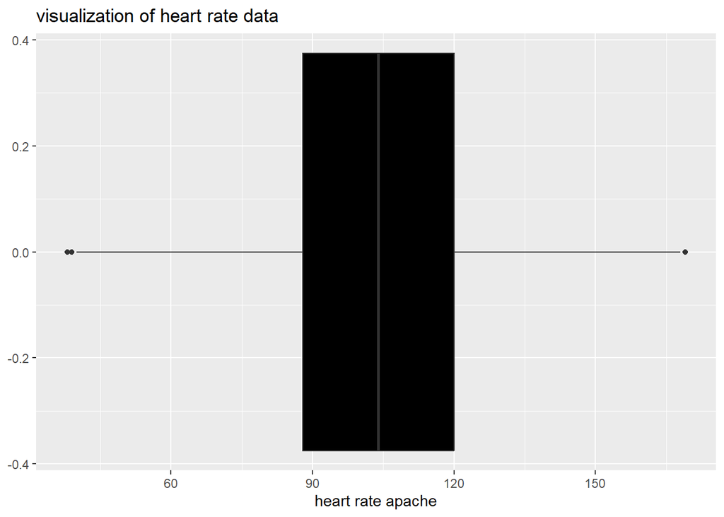

```r
ggplot(data=m,aes(x=heart_rate_apache,))+geom_boxplot(fill=c('black'))+labs(title="visualization of heart rate data",x="heart rate apache",)
```

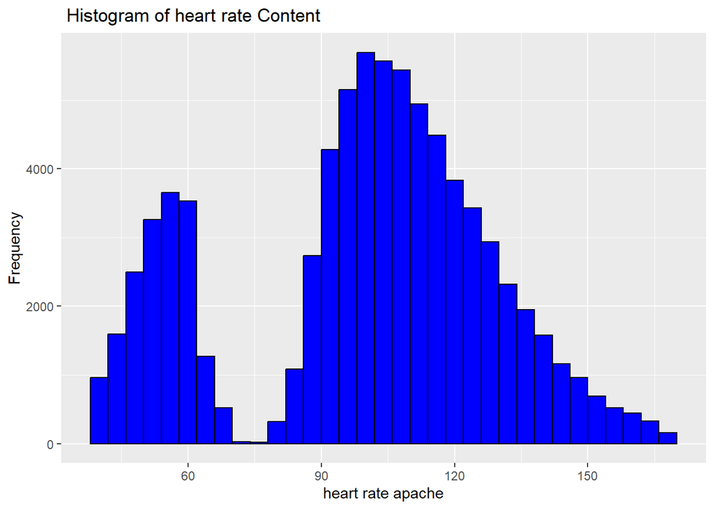

```r
ggplot(data=m, aes(x= heart_rate_apache )) + geom_histogram(binwidth= 4, fill ="blue", color = "black") + labs(title = " Histogram of heart rate Content", x= "heart rate apache", y = "Frequency")
```

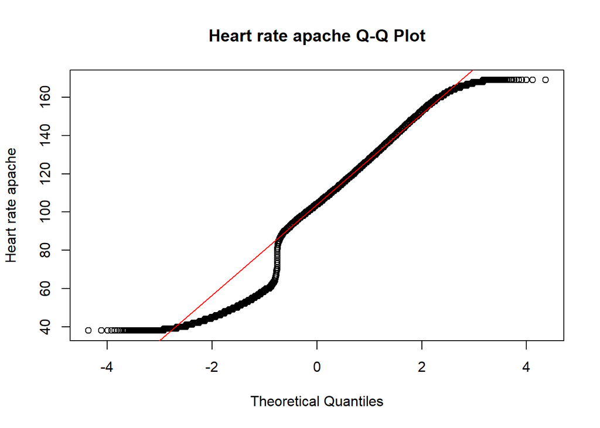

```r
qqnorm(m$heart_rate_apache, main = "Heart rate apache Q-Q Plot", ylab="Heart rate apache", datax=FALSE)
qqline(m$heart_rate_apache, col = "red")
```

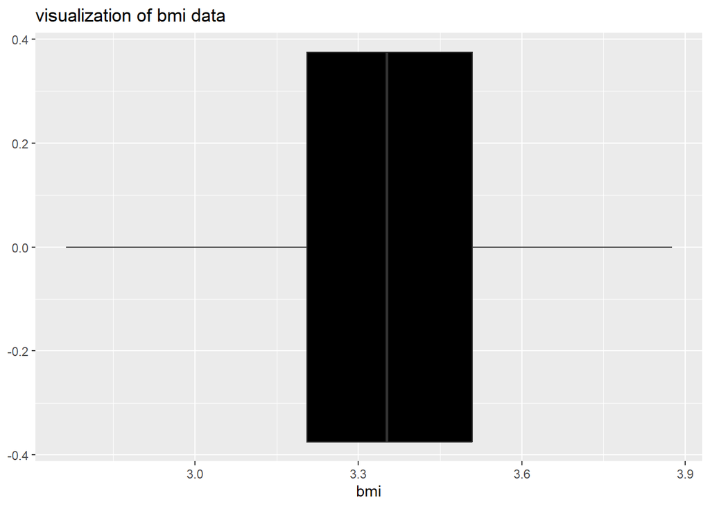

```r
ggplot(data=m,aes(x=bmi,))+geom_boxplot(fill=c('black'))+labs(title="visualization of bmi data",x="bmi",)
```

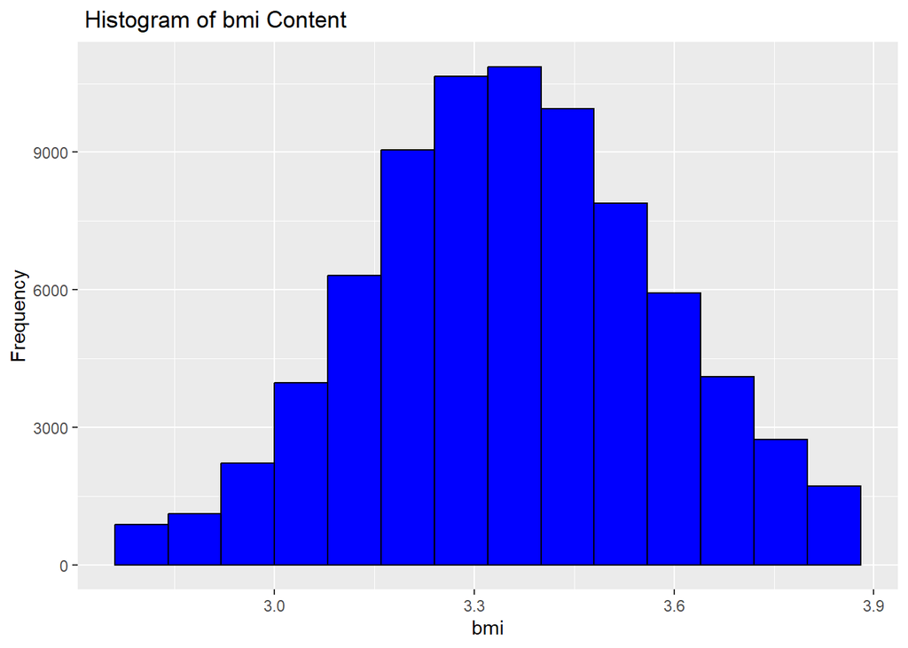

```r
ggplot(data=m, aes(x= bmi )) + geom_histogram(binwidth= 0.08, fill ="blue", color = "black") + labs(title = " Histogram of bmi Content", x= "bmi", y = "Frequency")
```

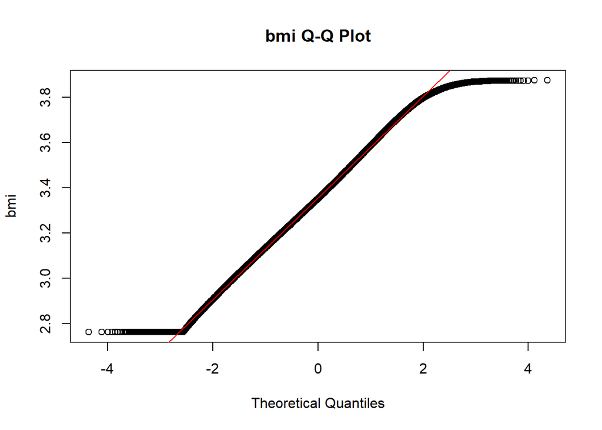

```r
qqnorm(m$bmi, main = "bmi Q-Q Plot", ylab="bmi", datax=FALSE)
qqline(m$bmi, col = "red")
```

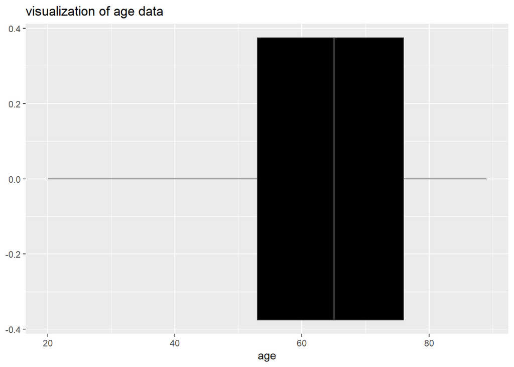

```r
ggplot(data=m,aes(x=age,))+geom_boxplot(fill=c('black'))+labs(title="visualization of age data",x="age",)
```

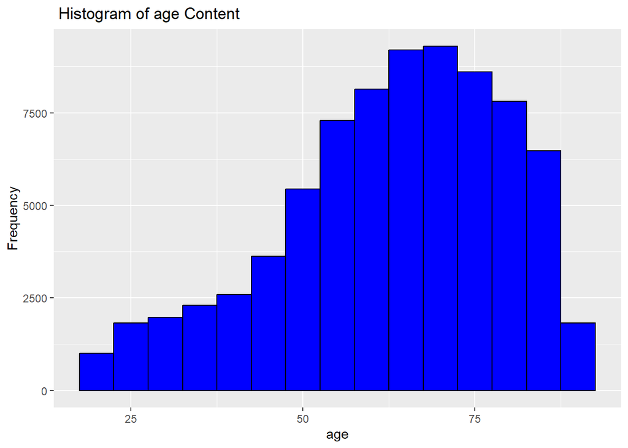

```r
ggplot(data=m, aes(x= age )) + geom_histogram(binwidth= 5, fill ="blue", color = "black") + labs(title = " Histogram of age Content", x= "age", y = "Frequency")
```

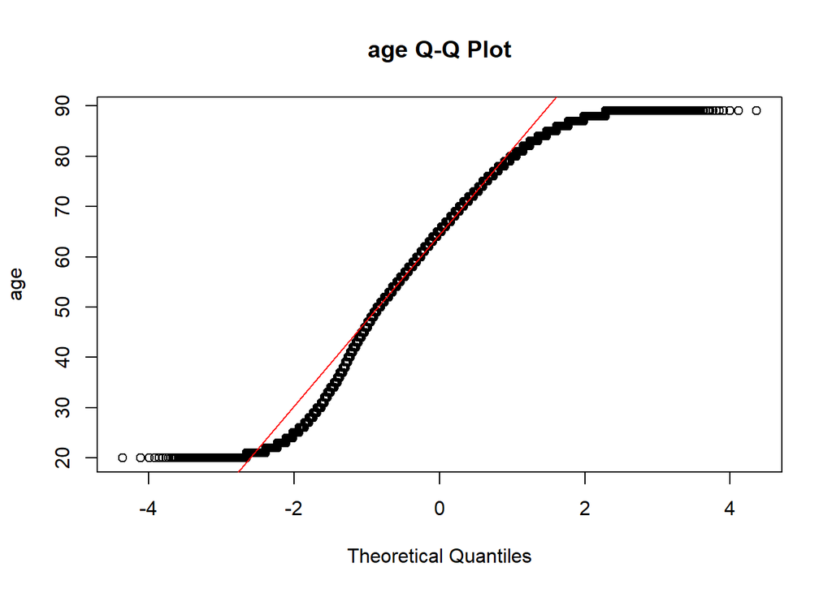

```r
qqnorm(m$age, main = "age Q-Q Plot", ylab="age", datax=FALSE)
qqline(m$age, col = "red")
```

T-test

A t-test is done to check whether the means of two samples (columns) have any difference. Here, the two sample t test has been done on heart rate against cirrhosis=0 and cirrhosis=1. Null Hypothesis H0: There is no difference between means. Alternate Hypothesis H1: There is significant difference between means. The output of the test revealed a p value ie., < 0.05 (95 percent confidence interval). Hence, we are rejecting the null hypothesis and stating that there is significant difference between the means. Since, there is significant difference between the means we can infer that cirrhosis has an impact on heart rate. This output followed the same pattern while comparing heart rate and other factors like diabetes, leukemia, hepatic failure and lymphoma.

```r
group_0 <- m$heart_rate_apache[m$cirrhosis == 0]
group_1 <- m$heart_rate_apache[m$cirrhosis == 1]

t_test_result <- t.test(group_0, group_1)

print(t_test_result)
```

```
##
##  Welch Two Sample t-test
##
## data:  group_0 and group_1
## t = -4, df = 1344, p-value = 3e-05
## alternative hypothesis: true difference in means is not equal to 0
## 95 percent confidence interval:
##  -4.83 -1.77
## sample estimates:
## mean of x mean of y
##      99.9     103.2
```

Correlation Matrix

A correlation matrix is used to identify relationships between multiple variables. Its outcome can be inferred in three ways., Positive correlation : Variables are directly proportional Zero correlation : There is no relation/dependency between variables Negative correlation : Variables are inversely proportional. The matrix has been drawn with heart rate, age and bmi as variables. Age: has negative correlation with heart rate and bmi Bmi: has negative correlation with heart rate

```r
#install.packages("corrplot")
library(corrplot)
cor_matrix <- cor(m[, c("heart_rate_apache", "bmi", "age")])
print(cor_matrix)
```

```
##                   heart_rate_apache     bmi     age
## heart_rate_apache            1.0000 -0.0536 -0.1406
## bmi                         -0.0536  1.0000 -0.0666
## age                         -0.1406 -0.0666  1.0000
```

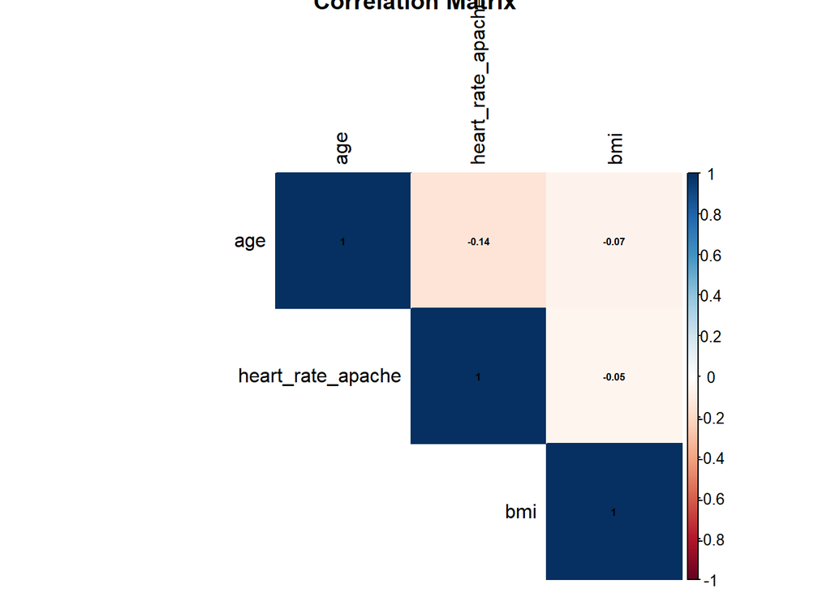

```r
corrplot(cor_matrix, method = "color",  type = "upper",
         #col = col(200),
         tl.col = "black",
         tl.srt = 90,
         order = "hclust",
         addCoef.col = "black",
         number.cex = 0.5,
         title = "Correlation Matrix", mar=c(0,0,0,0))
```